# Deteksi Infeksi Paru dengan Menggunakan Citra Lung X-ray

Muhammad Faris Muzakki

## Paper Terkait

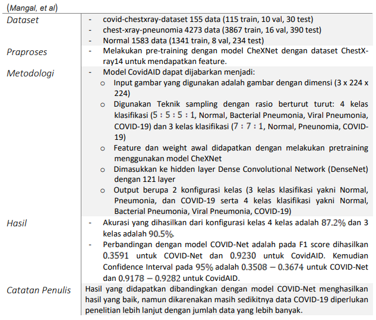

```python
from IPython.display import Image
Image('./assets/mangal_et_al.png')
```

Mangal, Arpan, et al. "CovidAID: COVID-19 detection using chest X-ray." arXiv preprint arXiv:2004.09803 (2020).

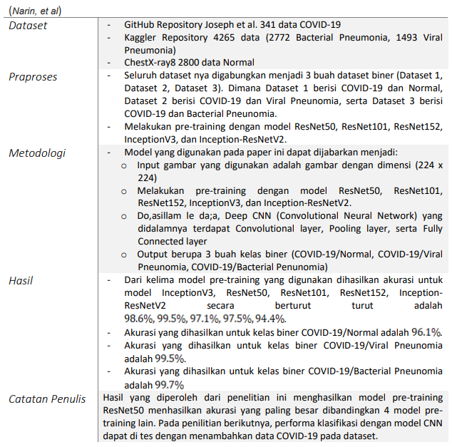

```python
Image('./assets/narin_et_al.png')
```

Narin, Ali, Ceren Kaya, and Ziynet Pamuk. "Automatic detection of coronavirus disease (covid-19) using x-ray images and deep convolutional neural networks." Pattern Analysis and Applications (2021): 1-14.

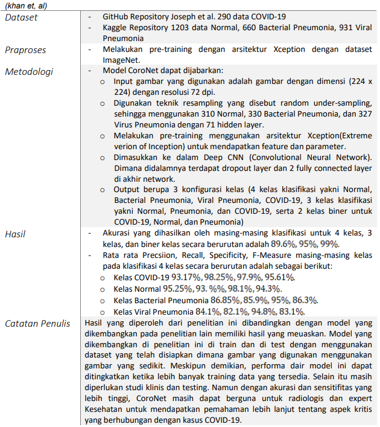

```python
Image('./assets/khan_et_al.png')
```

Khan, Asif Iqbal, Junaid Latief Shah, and Mohammad Mudasir Bhat. "CoroNet: A deep neural network for detection and diagnosis of COVID-19 from chest x-ray images." Computer Methods and Programs in Biomedicine 196 (2020): 105581.

### Catatan Penting

- Data yang kami gunakan diambil dari penelitian khan et al
- Akurasi klasifikasi biner (covid/non-covid) sudah sangat baik, akurasi berkisar antara 95% - 99%
- Akurasi Klasifikasi 3 kelas (covid/normal/pneumonia) sudah mencapai lebih dari 90%
- Akurasi Klasifikasi 4 kelas (covid/normal/pneumonia bactria/pneumonia viral) belum mencapai 90%
- Kami mengambil kasus 4 kelas klasifikasi

## Alur Pengerjaan

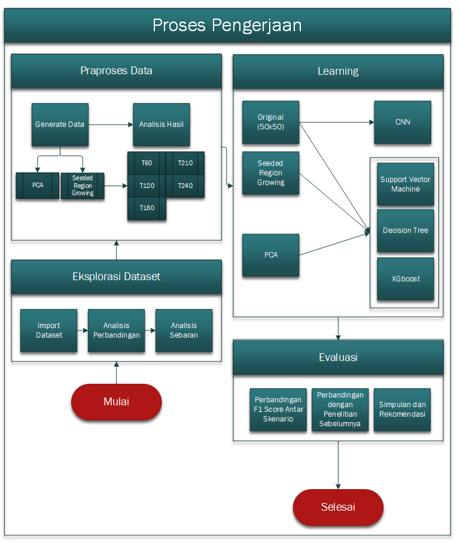

```python
Image('./charts/pengerjaan.png')
```

### Variabel

1. Variabel respon yang digunakan adalah F1 Score (weighted average)
2. Faktor / luaran yang di observasi adalah pengaruh praproses PCA dan Seeded Region Growing

## Eksplorasi Data

Dengan menggunakan 1 dataset, kami mengenerate dataset tersebut menjadi beberapa dataset berbeda, yaitu

```
1. dataset asli (resoulusi diubah menjadi 50x50) <br>
2. konversi PCA dengan dimensi jumlah dimensi = 30, 50 dan 100<br>
3. seeded region growing dengan threshold 60, 120, 180, 210, 240 <br>
```

Sehingga, kami memiliki dataset 9 yang di generate dari dataset yang sama

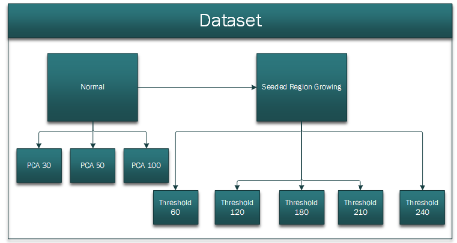

```python
Image('./charts/dataset4.png')
```

dataset didapatkan dari penelitian khan 2020  
https://www.sciencedirect.com/science/article/pii/S0169260720314140?casa_token=zkkevhSWL4IAAAAA:Uag69boqD48qnVXnRe_xTXeZjH_I6O97mYg_0O_fhwsYC4VqHzDSbUNhyn-DdGLtEQbcTE-EjO-6

### Import Dataset

```python
import cv2
import numpy as np
import os
# read images in folder
def read_image(path, is_gray_scale=False, is_region_growing=False):
    x = []
    y = []
    # iterate through the names of contents of the folder
    for image_label in os.listdir(path):
        if is_region_growing:
          path_label = path+image_label+'/none/'
        else:
          path_label = path+image_label + '/'

        for image_path in os.listdir(path_label):
          # create the full input path and read the file
          # 0 is grayscale
          if(is_gray_scale):
            image = cv2.imread(path_label + image_path, 0)
          else:
            image = cv2.imread(path_label + image_path)

          try:
              # resize image => all images are the same size
              image = cv2.resize(image, (50,50))
              if is_gray_scale:
                image = image.flatten()
              x.append(image)
              y.append(image_label)
          except:
              continue

    return np.array(x), np.array(y)
```

```python
dataset_path = 'dataset/original/'
x_deep_learning, y_deep_learning = read_image(dataset_path)
x, y = read_image(dataset_path, True)
```

```python
(unique, counts) = np.unique(y, return_counts=True)
frequencies = np.asarray((unique, counts)).T
```

```python
import pandas as pd
frequencies = [[x[0], int(x[1])] for x in frequencies]
frequencies = pd.DataFrame(frequencies, columns=['label','jumlah'])
frequencies
```

|  | label | jumlah |
| --- | --- | --- |
| 0 | covid | 320 |
| 1 | normal | 445 |
| 2 | pneumonia_bacterial | 449 |
| 3 | pneumonia_viral | 404 |

#### Contoh Dataset

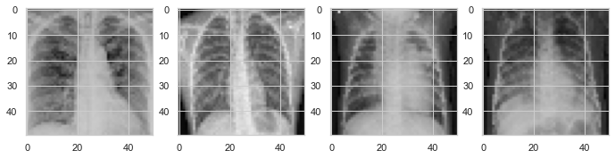

```python
import matplotlib.pyplot as plt

plt.figure()
#subplot(r,c) provide the no. of rows and columns
f, axarr = plt.subplots(1,4)

# use the created array to output your multiple images. In this case I have stacked 4 images vertically
axarr[0].imshow(x_deep_learning[12]) # covid
axarr[1].imshow(x_deep_learning[350]) # normal
axarr[2].imshow(x_deep_learning[800]) # pneumonia bac
axarr[3].imshow(x_deep_learning[1214]) # pneumonia vir
```

### Analisis Dataset

#### Plotting Jumlah Data

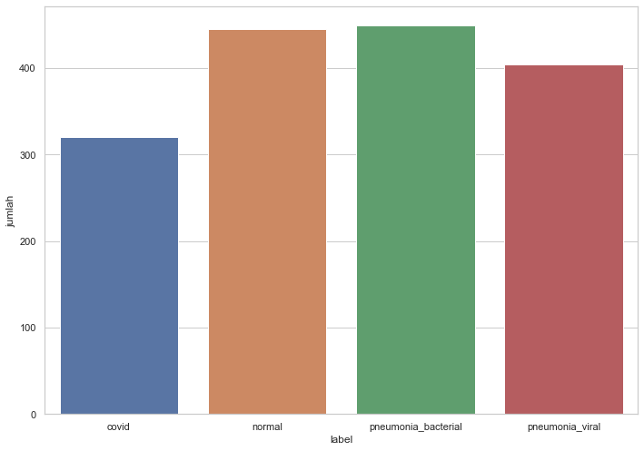

```python
import pandas as pd
import seaborn as sns

# join_analisis_dataset
sns.set(rc={'figure.figsize':(11.7,8.27)})
sns.set_theme(style='whitegrid')
ax = sns.barplot(x='label', y='jumlah', data=frequencies)
```

#### Plotting data dan label dengan PCA 2 Dimensi

```python
from sklearn.decomposition import PCA

pca = PCA(n_components=2)
analsis_dateset_pca = pca.fit_transform(x)
list_of_features = ['Feature' + str(x+ 1) for x in range(0, 2)]
analsis_dateset_pca = pd.DataFrame(data = analsis_dateset_pca, columns=list_of_features)
analsis_dateset_pca_y = pd.DataFrame(data = y, columns=['Label'])
analsis_dateset_pca = pd.concat([analsis_dateset_pca, analsis_dateset_pca_y], axis = 1)
```

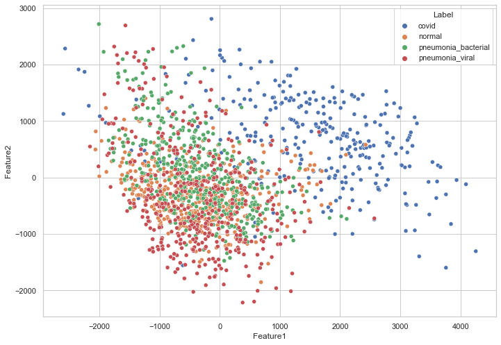

```python
ax = sns.scatterplot(x="Feature1", y="Feature2", hue="Label",
                   data=analsis_dateset_pca)
```

#### Plotting Importance Feature pada dimensi PCA

```python
from sklearn.ensemble import RandomForestClassifier

analisis_importance_feature = []
for i in [30, 50, 100]:
    pca = PCA(n_components=i)
    analsis_dateset_pca = pca.fit_transform(x)
    list_of_features = ['Feature' + str(x+1) for x in range(0, i)]
    analsis_dateset_pca = pd.DataFrame(data = analsis_dateset_pca, columns=list_of_features)
    analsis_dateset_pca_y = pd.DataFrame(data = y, columns=['Label'])
    analsis_dateset_pca = pd.concat([analsis_dateset_pca, analsis_dateset_pca_y], axis = 1)
    analisis_importance_feature.append(analsis_dateset_pca)
```

30 Dimensi

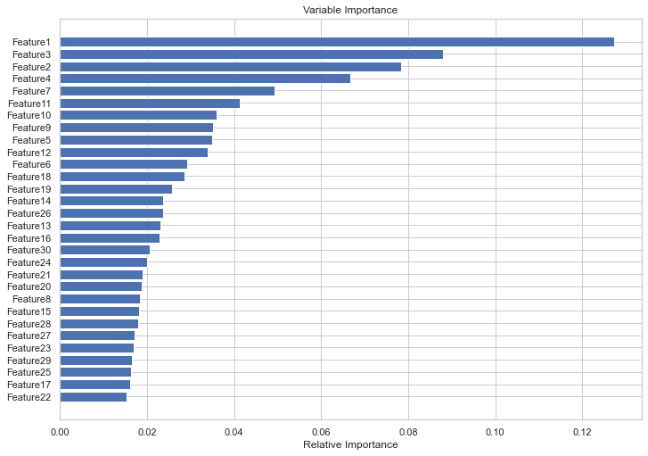

```python
features = np.array(['Feature' + str(x+1) for x in range(0,30)])
clf = RandomForestClassifier()
clf.fit(analisis_importance_feature[0][features], analisis_importance_feature[0]['Label'])
importances = clf.feature_importances_
sorted_idx = np.argsort(importances)
padding = np.arange(len(features)) + 0.5
plt.barh(padding, importances[sorted_idx], align='center')
plt.yticks(padding, features[sorted_idx])
plt.xlabel("Relative Importance")
plt.title("Variable Importance")
plt.show()
```

50 Dimensi

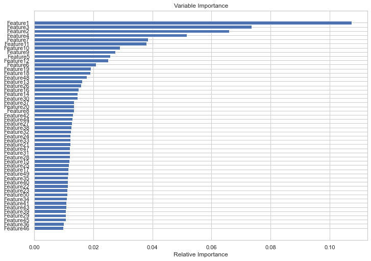

```python
features = np.array(['Feature' + str(x+1) for x in range(0,50)])
clf = RandomForestClassifier()
clf.fit(analisis_importance_feature[1][features], analisis_importance_feature[1]['Label'])
importances = clf.feature_importances_
sorted_idx = np.argsort(importances)
padding = np.arange(len(features)) + 0.5
plt.barh(padding, importances[sorted_idx], align='center')
plt.yticks(padding, features[sorted_idx])
plt.xlabel("Relative Importance")
plt.title("Variable Importance")
plt.show()
```

100 Dimensi

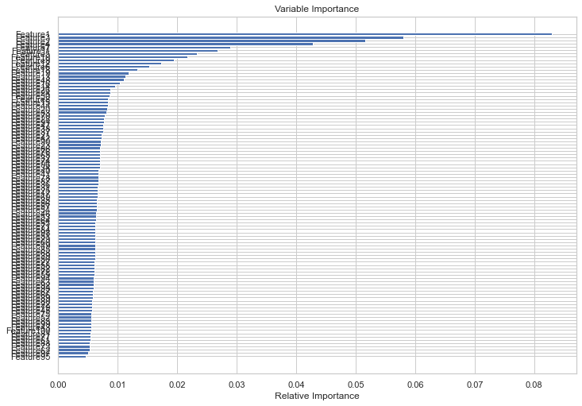

```python
features = np.array(['Feature' + str(x+1) for x in range(0,100)])
clf = RandomForestClassifier()
clf.fit(analisis_importance_feature[2][features], analisis_importance_feature[2]['Label'])
importances = clf.feature_importances_
sorted_idx = np.argsort(importances)
padding = np.arange(len(features)) + 0.5
plt.barh(padding, importances[sorted_idx], align='center')
plt.yticks(padding, features[sorted_idx])
plt.xlabel("Relative Importance")
plt.title("Variable Importance")
plt.show()
```

### Kesimpulan Hasil Analisis Dataset

- Dateset tidak memiliki permasalahan keseimbangan label (imbalance)
- data dengan label covid memiliki sebaran yang unik jika dibandingkan dengan label lainnya
- diantara PCA dengan dimensi 30, 50, 100, dimensi dengan jumlah 50 memiliki generalisasi terbaik.

## Praproses Data

### Generate Data (Seeded Region Growing)

```python
import random
import subprocess as sp
random.seed(1)

#fungsi merandom nama untuk menandai region
def random_color():
    r = random.randint(0,255)
    g = random.randint(0,255)
    b = random.randint(0,255)
    return r,g,b

#fungsi
def get8neighbors(x,y,shape):
    #output variabel
    coor = []

    #borderline
    maxx = shape[1]-1
    maxy = shape[0]-1
    minx = 0
    miny = 0

    #kiri atas ↖
    coorx = x - 1
    coory = y - 1
    if coorx <= maxx and coorx >= minx and coory <= maxy and coory >= miny:
        coor.append((coorx,coory))

    #atas tengah ↑
    coorx = x
    coory = y - 1
    if coorx <= maxx and coorx >= minx and coory <= maxy and coory >= miny:
        coor.append((coorx,coory))

    #atas kanan ↗
    coorx = x + 1
    coory = y - 1
    if coorx <= maxx and coorx >= minx and coory <= maxy and coory >= miny:
        coor.append((coorx,coory))

    #kiri ←
    coorx = x - 1
    coory = y
    if coorx <= maxx and coorx >= minx and coory <= maxy and coory >= miny:
        coor.append((coorx,coory))

    #kanan →
    coorx = x + 1
    coory = y
    if coorx <= maxx and coorx >= minx and coory <= maxy and coory >= miny:
        coor.append((coorx,coory))

    #bawah kiri ↙
    coorx = x - 1
    coory = y + 1
    if coorx <= maxx and coorx >= minx and coory <= maxy and coory >= miny:
        coor.append((coorx,coory))

    #bawah tengah ↓
    coorx = x
    coory = y + 1
    if coorx <= maxx and coorx >= minx and coory <= maxy and coory >= miny:
        coor.append((coorx,coory))

    #bawah kiri ↘
    coorx = x + 1
    coory = y + 1
    if coorx <= maxx and coorx >= minx and coory <= maxy and coory >= miny:
        coor.append((coorx,coory))

    return coor

#mencari nilai pixel maksimal pada cirta
def seed_point_search(pic):
    seed = -1 #inisiasi nilai seed
    for y, c in enumerate(pic):
        for x, d in enumerate(c):
            if pic[y][x] > seed:
                seed = pic[y][x]
    return seed

#mencari koordinat seed
def seed_point_coor(seed,pic):
    list_coor = []
    for y, c in enumerate(pic):
        for x, _ in enumerate(c):
            if pic[y][x]  == seed:
                list_coor.append([y,x])
    return list_coor

def region_growing(oripic,pic,seed,T,seedn):
    tmp = []
    resultimg = np.zeros_like(oripic) #penampung luaran segmentasi
    tmp.append((seed[0], seed[1]))
    processed = [] #penampung pixel yang sedang diproses
    r,g,b = random_color() #nilai untuk pewarnaan region
    pixel_counts = 0
    while(len(tmp) > 0):
        i = 0
        pix = tmp[0]
        #melakukan pengecekan kepada 8 tetangga pixel
        for coord in get8neighbors(pix[0], pix[1], pic.shape):
            if seedn - pic[coord[0], coord[1]] < T:
                resultimg[coord[0], coord[1],0] = b
                resultimg[coord[0], coord[1],1] = g
                resultimg[coord[0], coord[1],2] = r
                i += 1
                pixel_counts += 1
                #jika pixel yang akan diproses belum diproses sebelumnya
                if not coord in processed:
                    tmp.append(coord)
                #menambahkan daftar pixel yang sudah diproses dengan 8 tetangga
                processed.append(coord)
        tmp.pop(0)
        if i != 0:
            resultimg[pix[0], pix[1],0] = b
            resultimg[pix[0], pix[1],1] = g
            resultimg[pix[0], pix[1],2] = r
            pixel_counts += 1

    #minimal region yang diizinkan adalah 250 pixel
    # if pixel_counts < 50:
    #     resultimg = np.zeros_like(oripic)

    return resultimg

def segmentation_process(it,label,oripic,threshold):
    pic = cv2.cvtColor(oripic, cv2.COLOR_BGR2GRAY)
    # seedn = seed_point_search(pic)
    seedn = 255
    coor_seed = seed_point_coor(seedn,pic)
    T = threshold
    result = np.zeros_like(oripic)
    #melakukan loop untuk semua koordinat seed
    for _, c in enumerate(coor_seed):
        if result[c[0]][c[1],].all() == 0:
            tmp = region_growing(oripic,pic,c,T,seedn)
            result = result + tmp

    #Menyimpan luaran segmentasi
    # dir_path = 'D:/kuliah/S2/"Semester 1"/"Pengenalan Pola"/Tugas/"Tugas 7 Tubes Final"/'
    path = 'dataset/T'+ str(threshold) + '/' + label + '/'

    #hanya hasil segmentasi
    gray_scale_result = cv2.cvtColor(result, cv2.COLOR_BGR2GRAY)
    cv2.imwrite(path+'none/'+str(it)+'.jpg',gray_scale_result)

    #hasil segmentasi berdampingan dengan citra asli
    result = np.hstack((oripic,result))
    cv2.imwrite(path+'join/'+str(it)+'.jpg',result)
```

```python
import time
threshold_list = [60, 120, 180, 210, 240]
print('execution_time')
for threshold in threshold_list:
    start_time = time.time()
    for i in range(0, len(x_deep_learning)):
        segmentation_process(i,  y_deep_learning[i], x_deep_learning[i], threshold)
    exec_time = time.time() - start_time
    print('T' + str(threshold) + ' : ' + str(exec_time))
```

```
execution_time
T60 : 68.61393713951111
T120 : 305.998770236969
T180 : 1024.5265946388245
T210 : 1579.3111233711243
T240 : 1903.9373869895935
```

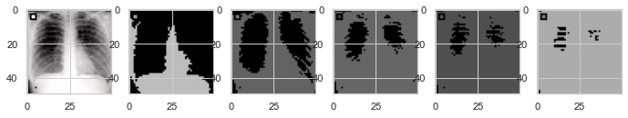

```python
original_covid = x_deep_learning[18]
t60_covid = cv2.imread('dataset/T60/covid/none/18.jpg')
t120_covid = cv2.imread('dataset/T120/covid/none/18.jpg')
t180_covid = cv2.imread('dataset/T180/covid/none/18.jpg')
t210_covid = cv2.imread('dataset/T210/covid/none/18.jpg')
t240_covid = cv2.imread('dataset/T240/covid/none/18.jpg')

f, axarr = plt.subplots(1,6)
# use the created array to output your multiple images. In this case I have stacked 4 images vertically
axarr[0].imshow(original_covid)
axarr[1].imshow(t60_covid)
axarr[2].imshow(t120_covid)
axarr[3].imshow(t180_covid)
axarr[4].imshow(t210_covid)
axarr[5].imshow(t240_covid)
```

### Analisis Luaran (Seeded Region Growing)

```python
x_srg_t60, y_srg_t60 = read_image('dataset/T60/', is_gray_scale=True, is_region_growing=True)
x_srg_t120, y_srg_t120 = read_image('dataset/T120/', is_gray_scale=True, is_region_growing=True)
x_srg_t180, y_srg_t180 = read_image('dataset/T180/', is_gray_scale=True, is_region_growing=True)
x_srg_t210, y_srg_t210 = read_image('dataset/T210/', is_gray_scale=True, is_region_growing=True)
x_srg_t240, y_srg_t240 = read_image('dataset/T240/', is_gray_scale=True, is_region_growing=True)
```

#### T60

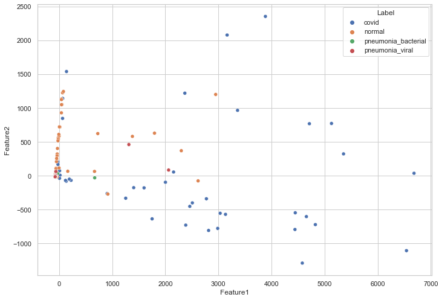

```python
pca = PCA(n_components=2)
analsis_dateset_pca = pca.fit_transform(x_srg_t60)
list_of_features = ['Feature' + str(x+ 1) for x in range(0, 2)]
analsis_dateset_pca = pd.DataFrame(data = analsis_dateset_pca, columns=list_of_features)
analsis_dateset_pca_y = pd.DataFrame(data = y_srg_t60, columns=['Label'])
analsis_dateset_pca = pd.concat([analsis_dateset_pca, analsis_dateset_pca_y], axis = 1)
axT60 = sns.scatterplot(x="Feature1", y="Feature2", hue="Label",
                   data=analsis_dateset_pca)
```

#### T120

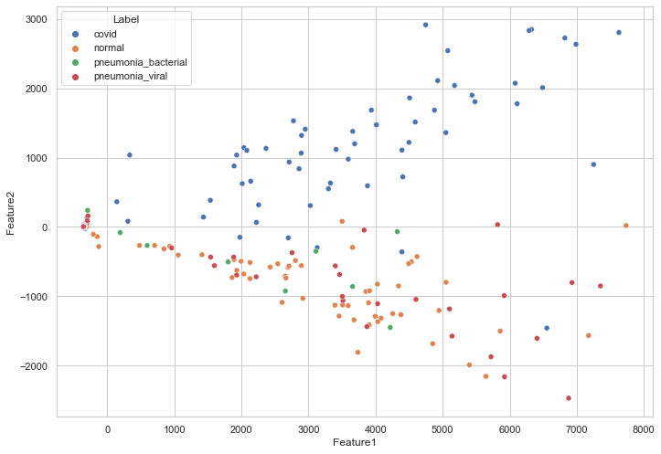

```python
pca = PCA(n_components=2)
analsis_dateset_pca = pca.fit_transform(x_srg_t120)
list_of_features = ['Feature' + str(x+ 1) for x in range(0, 2)]
analsis_dateset_pca = pd.DataFrame(data = analsis_dateset_pca, columns=list_of_features)
analsis_dateset_pca_y = pd.DataFrame(data = y_srg_t120, columns=['Label'])
analsis_dateset_pca = pd.concat([analsis_dateset_pca, analsis_dateset_pca_y], axis = 1)
axT120 = sns.scatterplot(x="Feature1", y="Feature2", hue="Label",
                   data=analsis_dateset_pca)
```

#### T180

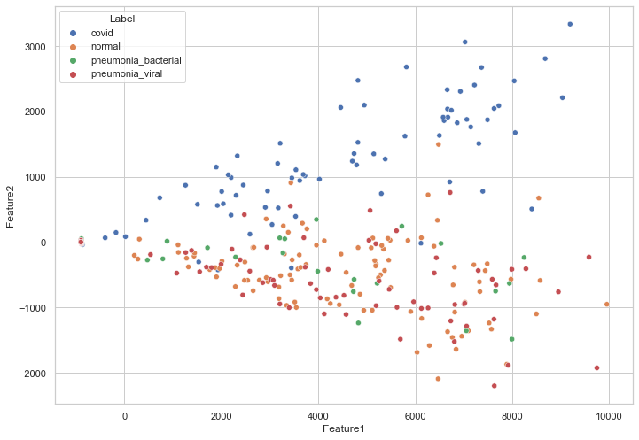

```python
pca = PCA(n_components=2)
analsis_dateset_pca = pca.fit_transform(x_srg_t180)
list_of_features = ['Feature' + str(x+ 1) for x in range(0, 2)]
analsis_dateset_pca = pd.DataFrame(data = analsis_dateset_pca, columns=list_of_features)
analsis_dateset_pca_y = pd.DataFrame(data = y_srg_t180, columns=['Label'])
analsis_dateset_pca = pd.concat([analsis_dateset_pca, analsis_dateset_pca_y], axis = 1)
ax180 = sns.scatterplot(x="Feature1", y="Feature2", hue="Label",
                   data=analsis_dateset_pca)
```

#### T210

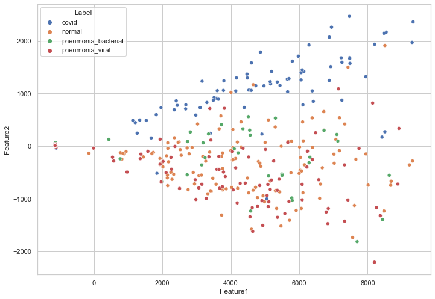

```python
pca = PCA(n_components=2)
analsis_dateset_pca = pca.fit_transform(x_srg_t210)
list_of_features = ['Feature' + str(x+ 1) for x in range(0, 2)]
analsis_dateset_pca = pd.DataFrame(data = analsis_dateset_pca, columns=list_of_features)
analsis_dateset_pca_y = pd.DataFrame(data = y_srg_t210, columns=['Label'])
analsis_dateset_pca = pd.concat([analsis_dateset_pca, analsis_dateset_pca_y], axis = 1)
ax210 = sns.scatterplot(x="Feature1", y="Feature2", hue="Label",
                   data=analsis_dateset_pca)
```

#### T240

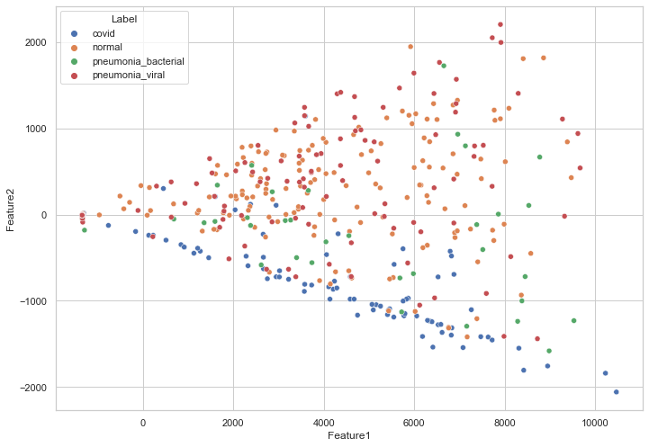

```python
pca = PCA(n_components=2)
analsis_dateset_pca = pca.fit_transform(x_srg_t240)
list_of_features = ['Feature' + str(x+ 1) for x in range(0, 2)]
analsis_dateset_pca = pd.DataFrame(data = analsis_dateset_pca, columns=list_of_features)
analsis_dateset_pca_y = pd.DataFrame(data = y_srg_t240, columns=['Label'])
analsis_dateset_pca = pd.concat([analsis_dateset_pca, analsis_dateset_pca_y], axis = 1)
ax240 = sns.scatterplot(x="Feature1", y="Feature2", hue="Label",
                   data=analsis_dateset_pca)
```

### Kesimpulan Hasil Praproses

- T210 dan T240 cenderung membuat sebaran label menjadi kurang variatif untuk kelas covid
- T120 dan T180 memberikan jarak atau sebaran yang baik untuk setiap label
- T60 membuat label selain covid menumpuk pada suatu sumbu x tertentu

## Learning

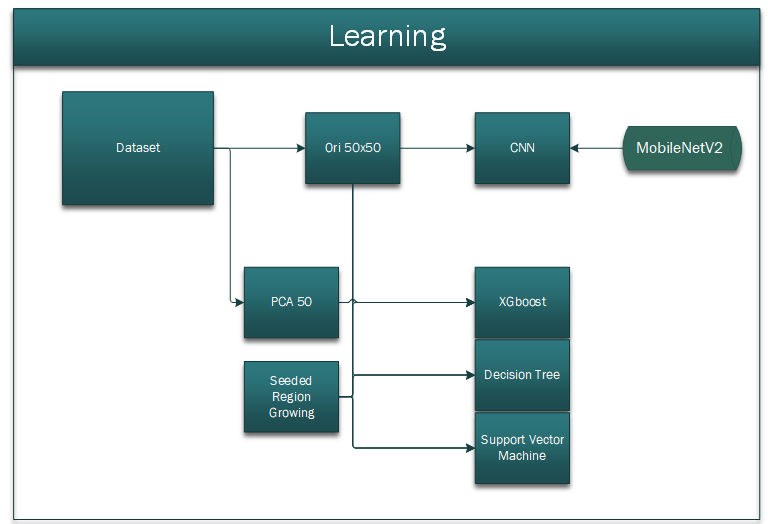

```python
Image('./charts/learning.png')
```

- Penggunaan Pre-trained model MobileNetV2 didasarkan pada running time dan biaya komputasi yang rendah. Juga, MobileNetV2 merupakan salah satu pre-trained model yang cukup stabil pada banyak kasus
- Sebelumnya, kami menggunakan pre-trained model X-Ception dan VGG19/16. Namun, estimasi running time untuk melakukan proses training sebanyak 4 Fold (250 epoch) adalah selama 4 dan 6 hari. Sehingga, tidak memungkinkan bagi kami untuk menggunakan pre-trained model dengan parameter yang sangat banyak (VGG19 mencapai 130juta, sedangkan MobileNetV2 hanya 3juta)

```python
list_of_features = ['Feature' + str(x+ 1) for x in range(0, 50)]
x_pca_50 = analisis_importance_feature[1][list_of_features].to_numpy()
y_pca_50 = analisis_importance_feature[1]['Label'].to_numpy()
```

```python
# dataset
## x_deep_learning, y_deep_learning = dataset normal 50x50
## x, y = dataset normal 50x50 yang sudah dilakukan proses flatten
## x_pca_50, y_pca_50 = dataset normal 50x50 yang sudah dilakukan proses pca 50 dimensi
## x_srg_60, y_srg_t60 = dataset seeded region growing 50x50 threshold = 60
## x_srg_120, y_srg_t120 = dataset seeded region growing 50x50 threshold = 120
## x_srg_180, y_srg_t180 = dataset seeded region growing 50x50 threshold = 180
## x_srg_210, y_srg_t210 = dataset seeded region growing 50x50 threshold = 210
## x_srg_240, y_srg_t240 = dataset seeded region growing 50x50 threshold = 240
```

### inisiasi KFold

```python
from sklearn.model_selection import KFold
kf = KFold(n_splits=4, random_state=10, shuffle=True)

train_index_list = []
val_index_list = []
for train_index, val_index in kf.split(x):
  train_index_list.append(train_index)
  val_index_list.append(val_index)
```

#### Sebaran Label KFold

```python
kfold1_check_train_y, kfold1_check_val_y  = y_deep_learning[train_index_list[0]], y_deep_learning[val_index_list[0]]
(unique1, counts1) = np.unique(kfold1_check_train_y, return_counts=True)
frequencies1 = np.asarray((unique1, counts1)).T
frequencies1 = [[x[0], int(x[1])] for x in frequencies1]
frequencies1 = pd.DataFrame(frequencies1, columns=['label','jumlah'])
print("Fold 1 - Train")
print(frequencies1.head())

(unique1, counts1) = np.unique(kfold1_check_val_y, return_counts=True)
frequencies1 = np.asarray((unique1, counts1)).T
frequencies1 = [[x[0], int(x[1])] for x in frequencies1]
frequencies1 = pd.DataFrame(frequencies1, columns=['label','jumlah'])
print("Fold 1 - Validation")
print(frequencies1.head())
```

```
Fold 1 - Train
                 label  jumlah
0                covid     242
1               normal     340
2  pneumonia_bacterial     338
3      pneumonia_viral     293
Fold 1 - Validation
                 label  jumlah
0                covid      78
1               normal     105
2  pneumonia_bacterial     111
3      pneumonia_viral     111
```

```python
kfold2_check_train_y, kfold2_check_val_y  = y_deep_learning[train_index_list[1]], y_deep_learning[val_index_list[1]]
(unique1, counts1) = np.unique(kfold2_check_train_y, return_counts=True)
frequencies1 = np.asarray((unique1, counts1)).T
frequencies1 = [[x[0], int(x[1])] for x in frequencies1]
frequencies1 = pd.DataFrame(frequencies1, columns=['label','jumlah'])
print("Fold 2 - Train")
print(frequencies1.head())

(unique1, counts1) = np.unique(kfold2_check_val_y, return_counts=True)
frequencies1 = np.asarray((unique1, counts1)).T
frequencies1 = [[x[0], int(x[1])] for x in frequencies1]
frequencies1 = pd.DataFrame(frequencies1, columns=['label','jumlah'])
print("Fold 2 - Validation")
print(frequencies1.head())
```

```
Fold 2 - Train
                 label  jumlah
0                covid     244
1               normal     339
2  pneumonia_bacterial     317
3      pneumonia_viral     313
Fold 2 - Validation
                 label  jumlah
0                covid      76
1               normal     106
2  pneumonia_bacterial     132
3      pneumonia_viral      91
```

```python
kfold3_check_train_y, kfold3_check_val_y  = y_deep_learning[train_index_list[2]], y_deep_learning[val_index_list[2]]
(unique1, counts1) = np.unique(kfold3_check_train_y, return_counts=True)
frequencies1 = np.asarray((unique1, counts1)).T
frequencies1 = [[x[0], int(x[1])] for x in frequencies1]
frequencies1 = pd.DataFrame(frequencies1, columns=['label','jumlah'])
print("Fold 3 - Train")
print(frequencies1.head())

(unique1, counts1) = np.unique(kfold3_check_val_y, return_counts=True)
frequencies1 = np.asarray((unique1, counts1)).T
frequencies1 = [[x[0], int(x[1])] for x in frequencies1]
frequencies1 = pd.DataFrame(frequencies1, columns=['label','jumlah'])
print("Fold 3 - Validation")
print(frequencies1.head())
```

```
Fold 3 - Train
                 label  jumlah
0                covid     237
1               normal     330
2  pneumonia_bacterial     340
3      pneumonia_viral     307
Fold 3 - Validation
                 label  jumlah
0                covid      83
1               normal     115
2  pneumonia_bacterial     109
3      pneumonia_viral      97
```

```python
kfold4_check_train_y, kfold4_check_val_y  = y_deep_learning[train_index_list[3]], y_deep_learning[val_index_list[3]]
(unique1, counts1) = np.unique(kfold4_check_train_y, return_counts=True)
frequencies1 = np.asarray((unique1, counts1)).T
frequencies1 = [[x[0], int(x[1])] for x in frequencies1]
frequencies1 = pd.DataFrame(frequencies1, columns=['label','jumlah'])
print("Fold 4 - Train")
print(frequencies1.head())

(unique1, counts1) = np.unique(kfold4_check_val_y, return_counts=True)
frequencies1 = np.asarray((unique1, counts1)).T
frequencies1 = [[x[0], int(x[1])] for x in frequencies1]
frequencies1 = pd.DataFrame(frequencies1, columns=['label','jumlah'])
print("Fold 4 - Validation")
print(frequencies1.head())
```

```
Fold 4 - Train
                 label  jumlah
0                covid     237
1               normal     326
2  pneumonia_bacterial     352
3      pneumonia_viral     299
Fold 4 - Validation
                 label  jumlah
0                covid      83
1               normal     119
2  pneumonia_bacterial      97
3      pneumonia_viral     105
```

Dapat disimpulkan bahwa sebaran label tiap fold relatif seimbang

### Deep Learning (CNN)

Arsitektur menggunakan paper referensi

#### Inisiasi Library

```python
from numpy.random import seed
import tensorflow
import keras
from tensorflow.keras.optimizers import Adam
from keras.models import Model, Sequential
from keras.layers import Input, Activation, Dense, Flatten
from keras.layers import Convolution2D, MaxPooling2D, ZeroPadding2D
tensorflow.random.set_seed(7)
seed(1)
```

#### Fungsi Plot Epoch

```python
#visualisasi proses training
import matplotlib.pyplot as plt
from keras import backend as K

dir_grafik_cnn = ""
class TrainingPlot(keras.callbacks.Callback):
    # this function will be executed since the start
    def on_train_begin(self, logs={}):
        # do initialization
        self.losses = []
        self.accuracy = []
        self.val_losses = []
        self.val_accuracy = []
        self.logs = []

    # this function will be executed when epoch finished
    def on_epoch_end(self, epoch, logs={}):
        # get the params of data
        self.logs.append(logs)
        self.losses.append(logs.get('loss'))
        self.accuracy.append(logs.get('accuracy'))
        self.val_losses.append(logs.get('val_loss'))
        self.val_accuracy.append(logs.get('val_accuracy'))

        if len(self.losses) > 1:
            N = np.arange(0, len(self.losses))
            # Ploting
            plt.plot(N, self.val_accuracy, 'y-', label="validation_accuracy")
            plt.plot(N, self.accuracy, 'b-', label="train_accuracy")
            plt.plot(N, self.losses, 'r-', label="train_loss")
            plt.plot(N, self.val_losses, 'g-', label="validation_loss")

            # show legend at first plot
            if(len(self.losses) == 2):
                plt.xlabel("Epoch #")
                plt.ylabel("Loss/Accuracy")
                plt.legend()
            # Save result to google drive
            plt.title("Loss & Accuracy [Epoch {}]".format(epoch+1))
            if((epoch + 1) % 50 == 0):
                plt.savefig(dir_grafik_cnn+'Epoch-{}.png'.format(epoch+1))

# Create object from TrainingPlot
plot_losses = TrainingPlot()
# Enter the matplotlib interactif mode
plt.ion()

def recall_m(y_true, y_pred):
    true_positives = K.sum(K.round(K.clip(y_true * y_pred, 0, 1)))
    possible_positives = K.sum(K.round(K.clip(y_true, 0, 1)))
    recall = true_positives / (possible_positives + K.epsilon())
    return recall

def precision_m(y_true, y_pred):
    true_positives = K.sum(K.round(K.clip(y_true * y_pred, 0, 1)))
    predicted_positives = K.sum(K.round(K.clip(y_pred, 0, 1)))
    precision = true_positives / (predicted_positives + K.epsilon())
    return precision

def f1_m(y_true, y_pred):
    precision = precision_m(y_true, y_pred)
    recall = recall_m(y_true, y_pred)
    return 2*((precision*recall)/(precision+recall+K.epsilon()))
```

#### Arsitektur

```python
from tensorflow.keras.applications import MobileNetV2
from tensorflow.python.keras import layers
from tensorflow.python.keras import models

conv_base = MobileNetV2(weights='imagenet',
                  include_top=False,
                  input_shape=(50, 50, 3))

conv_base.trainable = True
model = models.Sequential()
model.add(conv_base)
model.add(layers.Flatten())
model.add(layers.Dropout(0.5))
model.add(layers.Dense(256, activation='relu'))
model.add(layers.Dense(4, activation='softmax'))

model.compile(loss='categorical_crossentropy',
              optimizer='adam',
              metrics=['accuracy', f1_m, precision_m, recall_m])
```

```
WARNING:tensorflow:`input_shape` is undefined or non-square, or `rows` is not in [96, 128, 160, 192, 224]. Weights for input shape (224, 224) will be loaded as the default.
```

```python
def log_cnn(teks):
    file1 = open('learning/cnn/hasil.txt','a')
    file1.write(teks + '\n')
    file1.close()
```

#### Training

[output not shown]

[output cut: 11 more lines]

[output not shown]

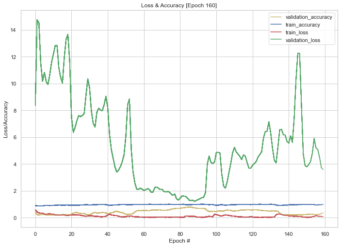

```python
from keras.callbacks import ModelCheckpoint
from sklearn.preprocessing import LabelBinarizer, LabelEncoder
from sklearn.metrics import confusion_matrix
labelEncoder = LabelEncoder()
labelBinarizer = LabelBinarizer()

for data in range(0, 1):
    ## data = 0 => original
    ## data = 1 => seeded region growing T120
    ## data = 2 => seeded region growing T180
    x_deep_cnn = []
    y_deep_cnn = []
    jenis_data = ""

    if(data == 0):
        x_deep_cnn = x_deep_learning
        y_deep_cnn = y_deep_learning
        jenis_data = 'original'

    if(data == 1):
        x_deep_cnn = x_srg_t120.reshape(50, 50, 1)
        y_deep_cnn = y_srg_t120
        jenis_data = 'T120'

    if(data == 2):
        x_deep_cnn = x_srg_t180
        y_deep_cnn = y_srg_t180
        jenis_data = 'T180'

    #encoding label
    y_deep_cnn = labelEncoder.fit_transform(y_deep_cnn)

    #Label Binerizing
    y_deep_cnn = labelBinarizer.fit_transform(y_deep_cnn)

    if(data != 0):
        log_cnn('\n')
    log_cnn(jenis_data)

    for fold in range(0, len(train_index_list)):
        checkpoint_path =  'learning/cnn/' + jenis_data + '/model/' + str(fold+1)
        dir_grafik_cnn = 'learning/cnn/' + jenis_data + '/grafik/' + str(fold+1) + '.png'

        #create checkpoint object
        # checkpoint = ModelCheckpoint(checkpoint_path, monitor='val_f1_m', verbose=1,
        #     save_best_only=True, mode='max')

        X_train, X_val = x_deep_cnn[train_index_list[fold],:],x_deep_cnn[val_index_list[fold],:]
        Y_train, Y_val = y_deep_cnn[train_index_list[fold]] , y_deep_cnn[val_index_list[fold]]

        hasil = model.fit(X_train, Y_train, validation_data=(X_val, Y_val),
            epochs=300, batch_size=302, callbacks=[plot_losses])

        loss, accuracy, f1_score, precision, recall = model.evaluate(X_val, Y_val, verbose=0)

        log_teks = 'Fold-' + str(fold+1) + ' : loss = ' + str(round(loss,4)) + ' acc = ' + \
            str(round(accuracy,4)) + ' f1_score = ' + str(round(f1_score,4)) + ' precision = ' + \
            str(round(precision,4)) + ' recall ' + str(round(recall,4))

        log_cnn(log_teks)
        plt.clf()

        # plot convusion matrix
        cf_matrix_path = 'learning/cnn/' + jenis_data + '/grafik/' + 'cf_' + str(fold+1) + '.png'
        Y_val_pred = model.predict(X_val)
        Y_val_pred = labelBinarizer.inverse_transform(Y_val_pred)
        Y_val = labelBinarizer.inverse_transform(Y_val)

        cf_matrix = confusion_matrix(Y_val_pred, Y_val, labels=[0, 1, 2, 3])
        cf_matrix = pd.DataFrame(cf_matrix, columns = ['covid', 'normal', 'pneumonia_bac', 'pneumonia_vir'], index= ['covid', 'normal', 'pneumonia_bac', 'pneumonia_vir'])
        cf_matrix = sns.heatmap(cf_matrix, annot=True)

        figure = cf_matrix.get_figure()
        figure.savefig(cf_matrix_path, dpi=400)
        plt.clf()
```

```python
model.summary()
```

```
Model: "sequential_10"
_________________________________________________________________
Layer (type)                 Output Shape              Param #
=================================================================
module_wrapper_10 (ModuleWra (None, 2, 2, 1280)        2257984
_________________________________________________________________
flatten_10 (Flatten)         (None, 5120)              0
_________________________________________________________________
dropout_10 (Dropout)         (None, 5120)              0
_________________________________________________________________
dense_20 (Dense)             (None, 256)               1310976
_________________________________________________________________
dense_21 (Dense)             (None, 4)                 1028
=================================================================
Total params: 3,569,988
Trainable params: 3,535,876
Non-trainable params: 34,112
_________________________________________________________________
```

Proses learning dihentikan, dikarenakan hasil yang tidak bagus  
Fold-1 : loss = 4.5605 acc = 0.4642 f1_score = 0.4497 precision = 0.45 recall 0.4495

```python
def define_model():
    model = models.Sequential()
    model.add(layers.Conv2D(50, (3, 3), activation='relu', input_shape=(50, 50, 3)))
    model.add(layers.MaxPooling2D((2, 2)))
    model.add(layers.Conv2D(64, (3, 3), activation='relu'))
    model.add(layers.MaxPooling2D((2, 2)))
    model.add(layers.Conv2D(64, (3, 3), activation='relu'))
    model.add(layers.Flatten())
    model.add(layers.Dropout(0.5))
    model.add(layers.Dense(64, activation='relu'))
    model.add(layers.Dense(10))
    model.add(layers.Dense(4, activation='softmax'))
    model.compile(loss='categorical_crossentropy',
        optimizer='adam', metrics=['accuracy', f1_m, precision_m, recall_m])

    return model
```

```python
model.summary()
```

```
Model: "sequential_13"
_________________________________________________________________
Layer (type)                 Output Shape              Param #
=================================================================
conv2d_6 (Conv2D)            (None, 48, 48, 50)        1400
_________________________________________________________________
max_pooling2d_4 (MaxPooling2 (None, 24, 24, 50)        0
_________________________________________________________________
conv2d_7 (Conv2D)            (None, 22, 22, 64)        28864
_________________________________________________________________
max_pooling2d_5 (MaxPooling2 (None, 11, 11, 64)        0
_________________________________________________________________
conv2d_8 (Conv2D)            (None, 9, 9, 64)          36928
_________________________________________________________________
flatten_13 (Flatten)         (None, 5184)              0
_________________________________________________________________
dropout_11 (Dropout)         (None, 5184)              0
_________________________________________________________________
dense_26 (Dense)             (None, 64)                331840
_________________________________________________________________
dense_27 (Dense)             (None, 10)                650
_________________________________________________________________
dense_28 (Dense)             (None, 4)                 44
=================================================================
Total params: 399,726
Trainable params: 399,726
Non-trainable params: 0
_________________________________________________________________
```

```python
 #encoding label
y_deep_cnn = labelEncoder.fit_transform(y_deep_learning)

#Label Binerizing
y_deep_cnn = labelBinarizer.fit_transform(y_deep_cnn)

x_deep_cnn = x_deep_learning

for fold in range(0, len(train_index_list)):
    model = define_model()
    checkpoint_path =  'learning/cnn/model/' + str(fold+1)
    dir_grafik_cnn = 'learning/cnn/grafik/' + str(fold+1) + '.png'

    #create checkpoint object
    checkpoint = ModelCheckpoint(checkpoint_path, monitor='val_f1_m', verbose=1,
        save_best_only=True, mode='max')

    X_train, X_val = x_deep_cnn[train_index_list[fold],:],x_deep_cnn[val_index_list[fold],:]
    Y_train, Y_val = y_deep_cnn[train_index_list[fold]] , y_deep_cnn[val_index_list[fold]]

    hasil = model.fit(X_train, Y_train, validation_data=(X_val, Y_val),
        epochs=250, batch_size=300, callbacks=[plot_losses, checkpoint])

    loss, accuracy, f1_score, precision, recall = model.evaluate(X_val, Y_val, verbose=0)

    log_teks = 'Fold-' + str(fold+1) + ' : loss = ' + str(round(loss,4)) + ' acc = ' + \
        str(round(accuracy,4)) + ' f1_score = ' + str(round(f1_score,4)) + ' precision = ' + \
        str(round(precision,4)) + ' recall ' + str(round(recall,4))

    log_cnn(log_teks)
    plt.clf()

    # plot convusion matrix
    cf_matrix_path = 'learning/cnn/grafik/' + 'cf_' + str(fold+1) + '.png'
    Y_val_pred = model.predict(X_val)
    Y_val_pred = labelBinarizer.inverse_transform(Y_val_pred)
    Y_val = labelBinarizer.inverse_transform(Y_val)

    cf_matrix = confusion_matrix(Y_val_pred, Y_val, labels=[0, 1, 2, 3])
    cf_matrix = pd.DataFrame(cf_matrix, columns = ['covid', 'normal', 'pneumonia_bac', 'pneumonia_vir'], index= ['covid', 'normal', 'pneumonia_bac', 'pneumonia_vir'])
    plt.figure(figsize = (14,13))
    cf_matrix = sns.heatmap(cf_matrix, annot=True)
    figure = cf_matrix.get_figure()

    figure.savefig(cf_matrix_path, dpi=400)
    plt.clf()
```

[output not shown]

[output cut: 2008 more lines]

```
Epoch 00243: val_f1_m did not improve from 0.16167

Epoch 00244: val_f1_m did not improve from 0.16167

Epoch 00245: val_f1_m did not improve from 0.16167

Epoch 00246: val_f1_m did not improve from 0.16167

Epoch 00247: val_f1_m did not improve from 0.16167

Epoch 00248: val_f1_m did not improve from 0.16167

Epoch 00249: val_f1_m did not improve from 0.16167

Epoch 00250: val_f1_m did not improve from 0.16167
```

#### Hasil Training CNN

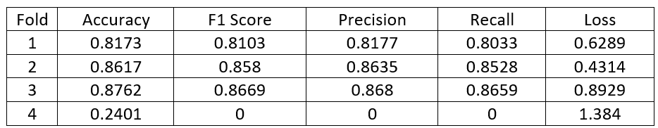

```python
Image('./learning/cnn/hasil.png')
```

Fold 1

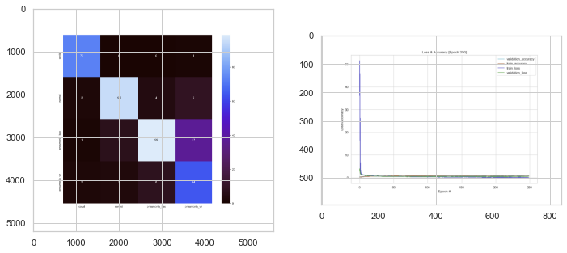

```python
cf = cv2.imread('learning/cnn/grafik/cf_1.png')
epoch = cv2.imread('learning/cnn/grafik/1.pngEpoch-250.png')

plt.figure()
f, axarr = plt.subplots(1,2)
axarr[0].imshow(cf)
axarr[1].imshow(epoch)
```

Fold 2

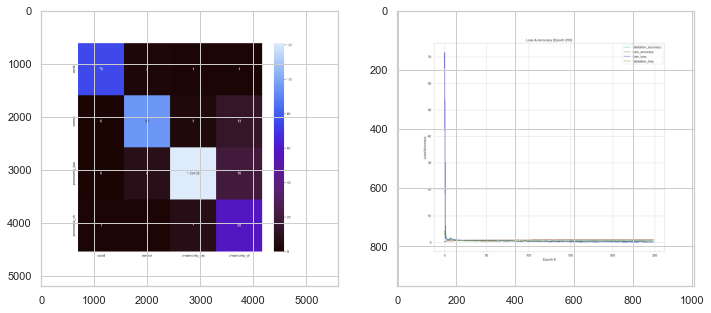

```python
cf = cv2.imread('learning/cnn/grafik/cf_2.png')
epoch = cv2.imread('learning/cnn/grafik/2.pngEpoch-250.png')

plt.figure()
f, axarr = plt.subplots(1,2)
axarr[0].imshow(cf)
axarr[1].imshow(epoch)
```

Fold 3

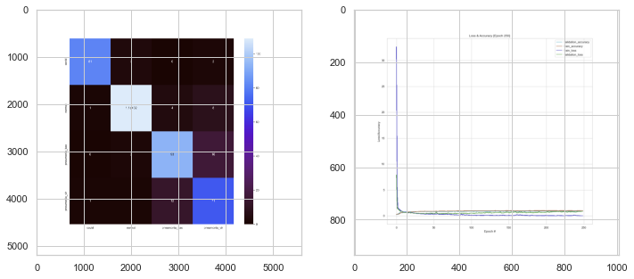

```python
cf = cv2.imread('learning/cnn/grafik/cf_3.png')
epoch = cv2.imread('learning/cnn/grafik/3.pngEpoch-250.png')

plt.figure()
f, axarr = plt.subplots(1,2)
axarr[0].imshow(cf)
axarr[1].imshow(epoch)
```

Fold 4

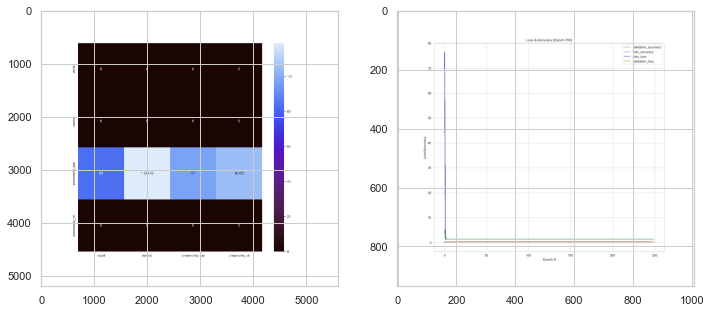

```python
cf = cv2.imread('learning/cnn/grafik/cf_4.png')
epoch = cv2.imread('learning/cnn/grafik/4.pngEpoch-250.png')

plt.figure()
f, axarr = plt.subplots(1,2)
axarr[0].imshow(cf)
axarr[1].imshow(epoch)
```

### Decision Tree

```python
def log_tree(teks):
    file1 = open('learning/decision_tree/hasil.txt','a')
    file1.write(teks + '\n')
    file1.close()
```

```python
from sklearn import tree
from sklearn.metrics import accuracy_score, f1_score

for jenis_data in range(0, 4):

    x_tree = []
    y_tree = []
    jenis_data_teks = ''
    if(jenis_data == 0):
        # normal
        x_tree = x
        y_tree = y
        jenis_data_teks = 'normal'

    elif(jenis_data == 1):
        # pc50
        x_tree = x_pca_50
        y_tree = y_pca_50
        jenis_data_teks = 'pc50'

    elif(jenis_data == 2):
        # T120
        x_tree = x_srg_t120
        y_tree = y_srg_t120
        jenis_data_teks = 't120'

    elif(jenis_data == 3):
        # T180
        x_tree = x_srg_t180
        y_tree = y_srg_t180
        jenis_data_teks = 't180'

    log_tree(jenis_data_teks)
    for fold in range(0, len(train_index_list)):
        cf_matrix_path = 'learning/decision_tree/' + jenis_data_teks + '_' + str(fold+1) + '.png'

        X_train, X_val = x_tree[train_index_list[fold],:], x_tree[val_index_list[fold],:]
        Y_train, Y_val = y_tree[train_index_list[fold]], y_tree[val_index_list[fold]]

        clf = tree.DecisionTreeClassifier()
        clf = clf.fit(X_train, Y_train)

        Y_pred = clf.predict(X_val)

        cf_matrix = confusion_matrix(Y_pred, Y_val, labels=['covid', 'normal', 'pneumonia_bacterial', 'pneumonia_viral'])
        cf_matrix = pd.DataFrame(cf_matrix, columns=['covid', 'normal', 'pneumonia_bacterial', 'pneumonia_viral'], index=['covid', 'normal', 'pneumonia_bacterial', 'pneumonia_viral'])
        plt.figure(figsize = (14,13))
        cf_matrix = sns.heatmap(cf_matrix, annot=True)
        figure = cf_matrix.get_figure()

        figure.savefig(cf_matrix_path, dpi=400)

        akurasi = round(accuracy_score(Y_val, Y_pred), 4)
        f1 = round(f1_score(Y_val, Y_pred, zero_division=1, average='weighted'), 4)
        teks_log = 'Fold-' + str(fold+1) + ' : accuracy = ' + str(akurasi) + ' f1_score = ' + str(f1)
        log_tree(teks_log)

    log_tree('\n')
```

#### Hasil Training Decision Tree

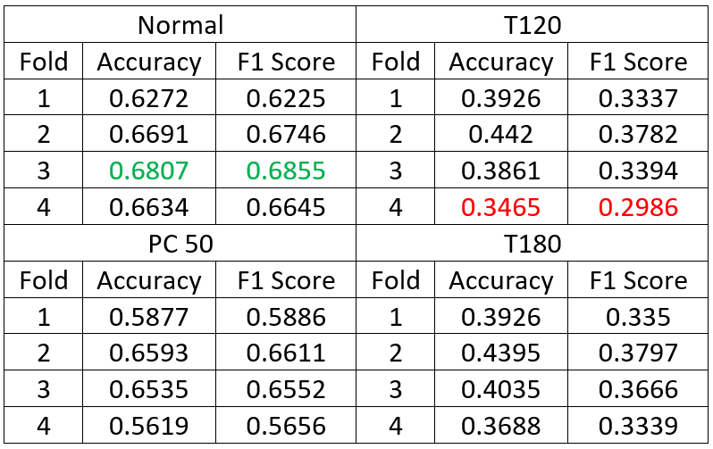

```python
Image('./learning/decision_tree/hasil2.png')
```

### Support Vector Machine

```python
def log_svm(teks):
    file1 = open('learning/svm/hasil.txt','a')
    file1.write(teks + '\n')
    file1.close()
```

```python
from sklearn import svm

for jenis_data in range(0, 4):

    x_svm = []
    y_svm = []
    jenis_data_teks = ''

    if(jenis_data == 0):
        # normal
        x_svm = x
        y_svm = y
        jenis_data_teks = 'normal'

    elif(jenis_data == 1):
        # pc50
        x_svm = x_pca_50
        y_svm = y_pca_50
        jenis_data_teks = 'pc50'

    elif(jenis_data == 2):
        # T120
        x_svm = x_srg_t120
        y_svm = y_srg_t120
        jenis_data_teks = 't120'

    elif(jenis_data == 3):
        # T180
        x_svm = x_srg_t180
        y_svm = y_srg_t180
        jenis_data_teks = 't180'

    log_svm(jenis_data_teks)
    for fold in range(0, len(train_index_list)):
        cf_matrix_path = 'learning/svm/' + jenis_data_teks + '_' + str(fold+1) + '.png'

        X_train, X_val = x_svm[train_index_list[fold],:], x_svm[val_index_list[fold],:]
        Y_train, Y_val = y_svm[train_index_list[fold]], y_svm[val_index_list[fold]]

        clf = svm.SVC()
        clf = clf.fit(X_train, Y_train)

        Y_pred = clf.predict(X_val)

        cf_matrix = confusion_matrix(Y_pred, Y_val, labels=['covid', 'normal', 'pneumonia_bacterial', 'pneumonia_viral'])
        cf_matrix = pd.DataFrame(cf_matrix, columns=['covid', 'normal', 'pneumonia_bacterial', 'pneumonia_viral'], index=['covid', 'normal', 'pneumonia_bacterial', 'pneumonia_viral'])
        plt.figure(figsize = (14,13))
        cf_matrix = sns.heatmap(cf_matrix, annot=True)
        figure = cf_matrix.get_figure()

        figure.savefig(cf_matrix_path, dpi=400)

        akurasi = round(accuracy_score(Y_val, Y_pred), 4)
        f1 = round(f1_score(Y_val, Y_pred, zero_division=1, average='weighted'), 4)
        teks_log = 'Fold-' + str(fold+1) + ' : accuracy = ' + str(akurasi) + ' f1_score = ' + str(f1)
        log_svm(teks_log)

    log_svm('\n')
```

#### Hasil Training Support Vector Machine

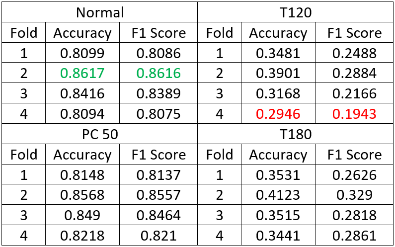

```python
Image('./learning/svm/hasil2.png')
```

### XGboost

```python
def log_xgboost(teks):
    file1 = open('learning/xgboost/hasil.txt','a')
    file1.write(teks + '\n')
    file1.close()
```

```python
from xgboost import XGBClassifier

for jenis_data in range(0, 4):

    x_xgboost = []
    y_xgboost = []
    jenis_data_teks = ''

    if(jenis_data == 0):
        # normal
        x_xgboost = x
        y_xgboost = y
        jenis_data_teks = 'normal'

    elif(jenis_data == 1):
        # pc50
        x_xgboost = x_pca_50
        y_xgboost = y_pca_50
        jenis_data_teks = 'pc50'

    elif(jenis_data == 2):
        # T120
        x_xgboost = x_srg_t120
        y_xgboost = y_srg_t120
        jenis_data_teks = 't120'

    elif(jenis_data == 3):
        # T180
        x_xgboost = x_srg_t180
        y_xgboost = y_srg_t180
        jenis_data_teks = 't180'

    log_xgboost(jenis_data_teks)
    for fold in range(0, len(train_index_list)):
        cf_matrix_path = 'learning/xgboost/' + jenis_data_teks + '_' + str(fold+1) + '.png'

        X_train, X_val = x_xgboost[train_index_list[fold],:], x_xgboost[val_index_list[fold],:]
        Y_train, Y_val = y_xgboost[train_index_list[fold]], y_xgboost[val_index_list[fold]]

        clf = XGBClassifier()
        clf.fit(X_train, Y_train)

        Y_pred = clf.predict(X_val)

        cf_matrix = confusion_matrix(Y_pred, Y_val, labels=['covid', 'normal', 'pneumonia_bacterial', 'pneumonia_viral'])
        cf_matrix = pd.DataFrame(cf_matrix, columns=['covid', 'normal', 'pneumonia_bacterial', 'pneumonia_viral'], index=['covid', 'normal', 'pneumonia_bacterial', 'pneumonia_viral'])
        plt.figure(figsize = (14,13))
        cf_matrix = sns.heatmap(cf_matrix, annot=True)
        figure = cf_matrix.get_figure()

        figure.savefig(cf_matrix_path, dpi=400)

        akurasi = round(accuracy_score(Y_val, Y_pred), 4)
        f1 = round(f1_score(Y_val, Y_pred, zero_division=1, average='weighted'), 4)
        teks_log = 'Fold-' + str(fold+1) + ' : accuracy = ' + str(akurasi) + ' f1_score = ' + str(f1)
        log_xgboost(teks_log)

    log_xgboost('\n')
```

#### Hasil Training XGBoost

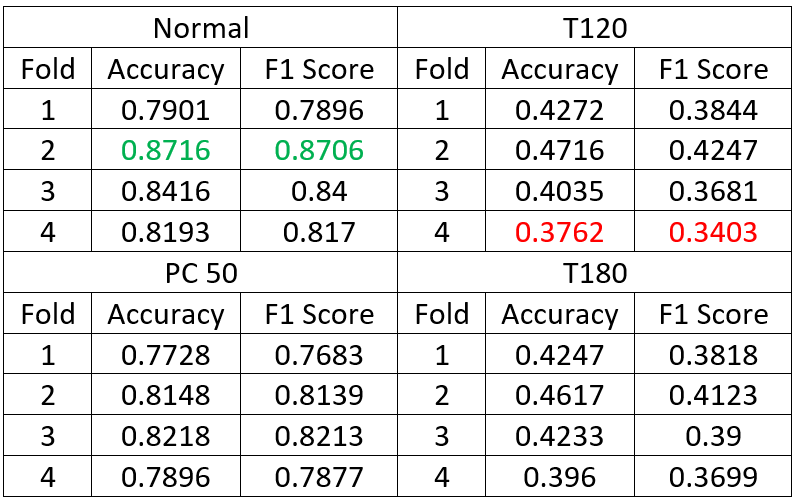

```python
Image('./learning/xgboost/hasil2.png')
```

## Hasil dan Evaluasi

### Penelitian Terdahulu

- Akurasi/F1 yang kami hasilkan, belum bisa menyamai jurnal terbaik
- Terbaik jurnal (akurasi 89.6%) terbaik kami (87.6%)
- Akurasi terbaik yang didapatkan oleh jurnal menggunakan algoritma CNN dengan pre-model X-Ception

### Saran

- Menggunakan dataset yang lebih besar. Saat ini sudah tersedia dataset x-ray pneumonia dan normal (tidak ada covid) dengan jumlah lebih dari 5000 instances. (https://www.kaggle.com/c/rsna-pneumonia-detection-challenge/overview)
- Mencoba menggunakan Pre-model VGG19 (membutuhkan komputer yang mumpuni)
- Praproses citra dilakukan dengan algoritma yang tidak berhubungan dengan threshold skala keabuan. Atau bisa juga menggunakan algoritma untuk membuat normalisasi pencahayaan terlebih dahulu